# Taller de R básico. Dia 4.

Viacheslav Shalisko

20 de octubre de 2016

### A. Cargar la tabla de datos

#### Estructura de datos (tabla `Datos_del_censo.csv`):

1. *Centro* - código del CU
2. *Especie* - nombre científico
3. *Codigo* - identificador único del arbol
4. *AB* - área basal del árbol (dm<sup>2</sup>)
5. *DTr* - diametro del tronco equivalente (cm)
6. *Alt* - estatura del árbol (m)
7. *DCop* - diametro promedio de la copa (m)
8. *ExcCop* - excentricidad de la copa

```r
arbolado <- read.csv("Materiales/Datos_del_censo.csv")
```

### Partes B. y C. fueron tratados en la sesión anterior.

Continuación

### D. Gráficas simples

#### Histogramas

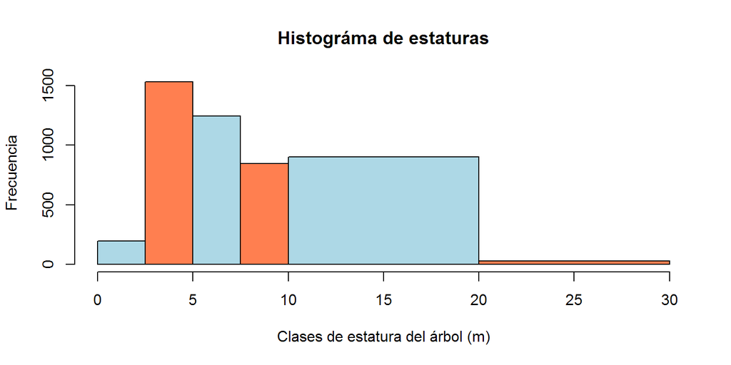

```r
H0 <- hist(arbolado$Alt,
     col = c("lightblue","coral"),
     xlab = "Clases de estatura del árbol (m)", ylab = "Frecuencia",
     main = "Histográma de estaturas",
     breaks = c(0,2.5,5,7.5,10,20,30), prob = FALSE)
```

```r
str(H0)
```

```
## List of 6
##  $ breaks  : num [1:7] 0 2.5 5 7.5 10 20 30
##  $ counts  : int [1:6] 196 1529 1242 844 900 28
##  $ density : num [1:6] 0.0165 0.1291 0.1048 0.0712 0.019 ...
##  $ mids    : num [1:6] 1.25 3.75 6.25 8.75 15 25
##  $ xname   : chr "arbolado$Alt"
##  $ equidist: logi FALSE
##  - attr(*, "class")= chr "histogram"
```

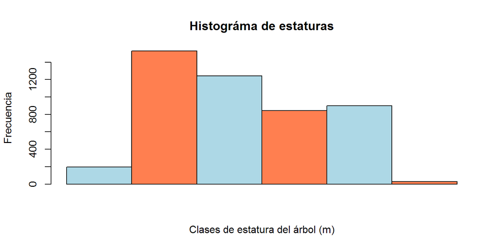

```r
barplot(H0$counts, space = 0,
     col = c("lightblue","coral"),
     xlab = "Clases de estatura del árbol (m)", ylab = "Frecuencia",
     main = "Histográma de estaturas")
```

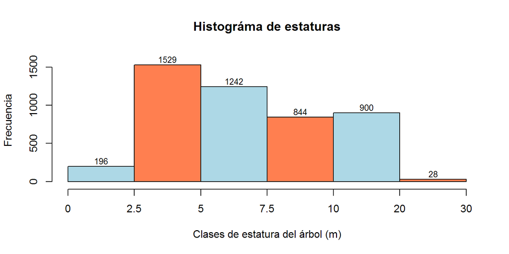

```r
B0 <- barplot(H0$counts, space = 0, ylim = c(-100,1700),
     col = c("lightblue","coral"),
     xlab = "Clases de estatura del árbol (m)", ylab = "Frecuencia",
     main = "Histográma de estaturas")
axis(at = seq(from = 0, to = 6, by = 1),
     labels = c(0,2.5,5,7.5,10,20,30), side = 1)
text(B0, H0$counts + 0.05 * max(H0$counts), labels=round(H0$counts), cex = 0.8)
```

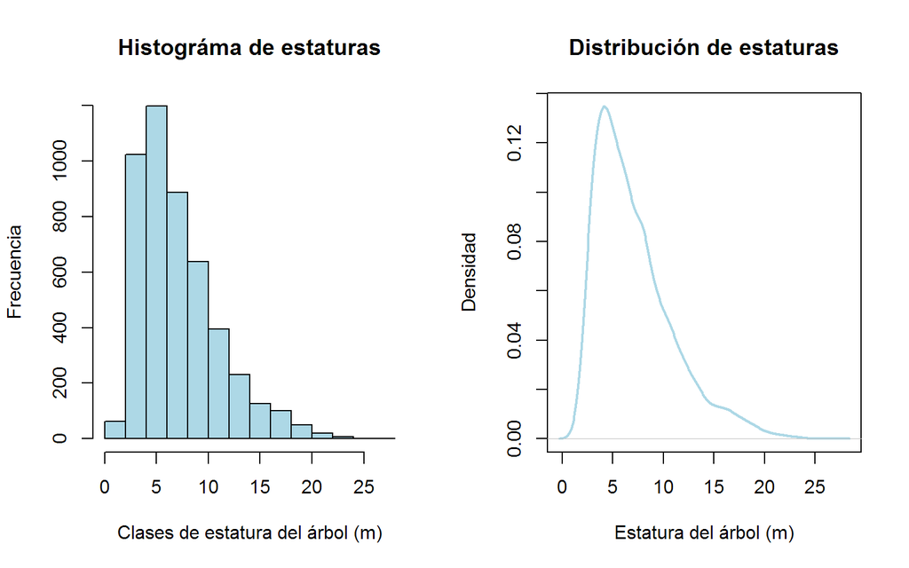

```r
par(mfcol = c(1, 2))

hist(arbolado$Alt,
     col = c("lightblue"),
     xlab = "Clases de estatura del árbol (m)", ylab = "Frecuencia",
     main = "Histográma de estaturas", prob = FALSE)

plot(density(arbolado$Alt, na.rm = TRUE),
     col = c("lightblue"), lty=1, lwd=2,
     xlab = "Estatura del árbol (m)", ylab = "Densidad",
     main = "Distribución de estaturas")
```

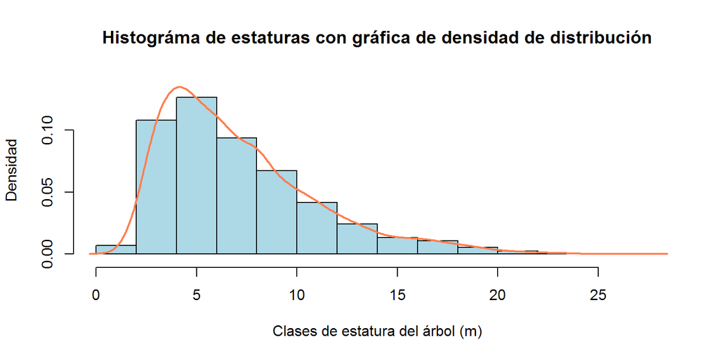

```r
H1 <- hist(arbolado$Alt, ylim = c(-0.005,0.14),
     col = c("lightblue"),
     xlab = "Clases de estatura del árbol (m)", ylab = "Densidad",
     main = "Histográma de estaturas con gráfica de densidad de distribución", prob = TRUE)

densidad <- density(arbolado$Alt, na.rm = TRUE)
lines(densidad, col = c("coral"), lty=1, lwd=2)
```

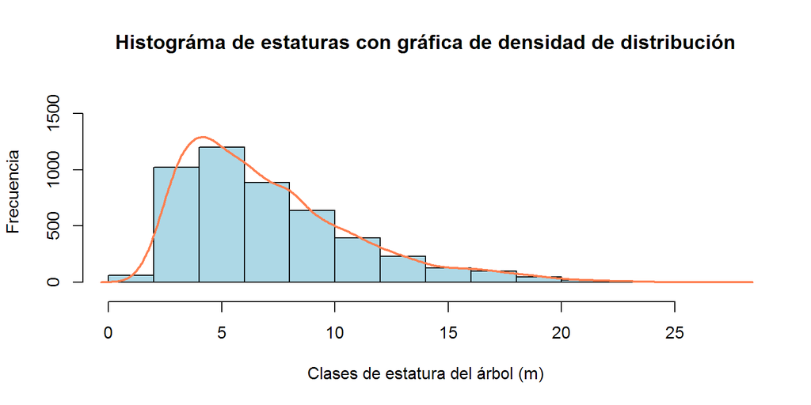

```r
H2 <- hist(arbolado$Alt, ylim = c(-100,1700),
     col = c("lightblue"),
     xlab = "Clases de estatura del árbol (m)", ylab = "Frecuencia",
     main = "Histográma de estaturas con gráfica de densidad de distribución", prob = FALSE)

densidad <- density(arbolado$Alt, na.rm = TRUE)
densidad$y <- densidad$y*diff(H2$mids[1:2])*length(arbolado$Alt)
lines(densidad, col = c("coral"), lty=1, lwd=2)
```

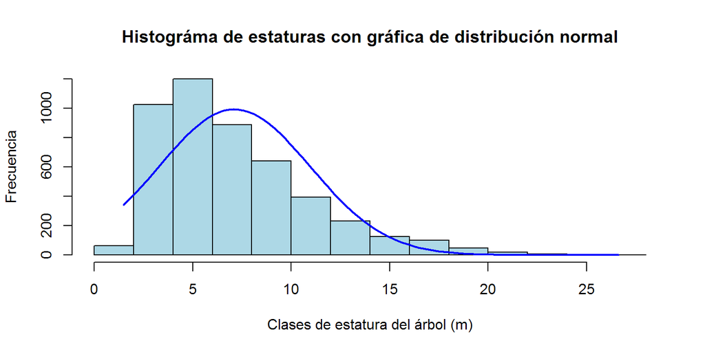

```r
plot(H1, col = c("lightblue"),
     xlab = "Clases de estatura del árbol (m)", ylab = "Frecuencia",
     main = "Histográma de estaturas con gráfica de distribución normal")

xfit<-seq(min(arbolado$Alt, na.rm = TRUE),max(arbolado$Alt, na.rm = TRUE),length=100)
yfit<-dnorm(xfit,mean=mean(arbolado$Alt, na.rm = TRUE),sd=sd(arbolado$Alt, na.rm = TRUE))
yfit <- yfit*diff(H1$mids[1:2])*length(arbolado$Alt)
lines(xfit, yfit, col="blue", lwd=2)
```

#### Gráficas QQ

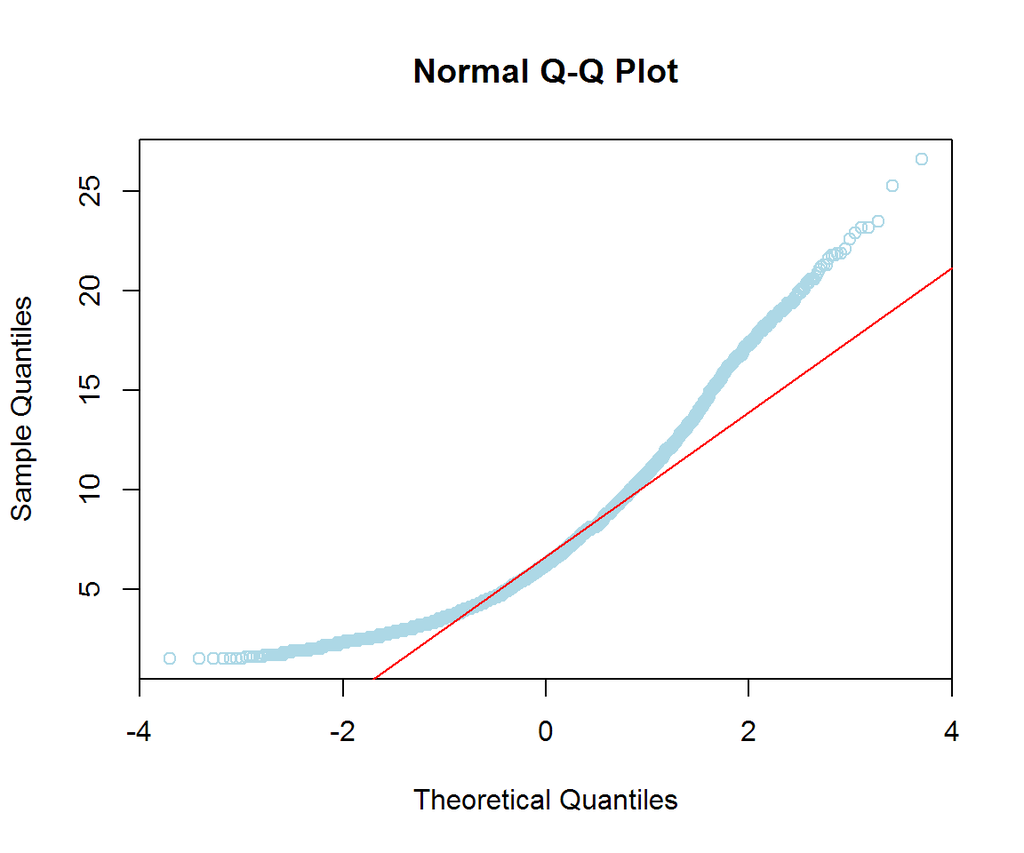

```r
qqnorm(arbolado$Alt, col = "lightblue")
qqline(arbolado$Alt, col = "red")
```

#### Gráficas de caja

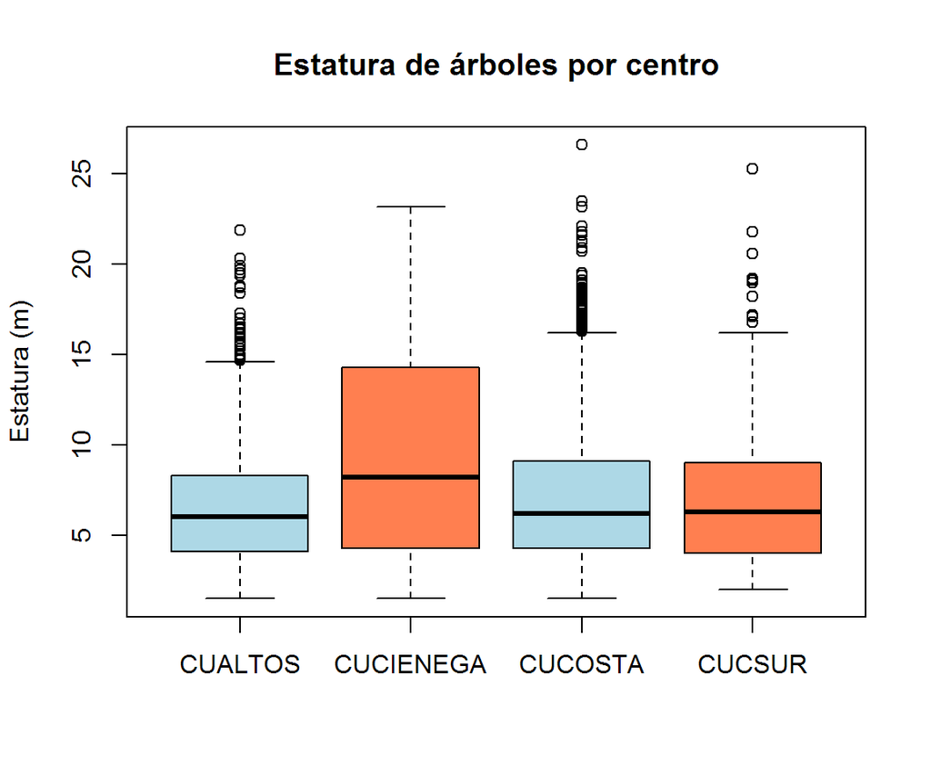

```r
boxplot(arbolado$Alt ~ arbolado$Centro,
        col = c("lightblue","coral"),
        main = "Estatura de árboles por centro",
        ylab = "Estatura (m)")
```

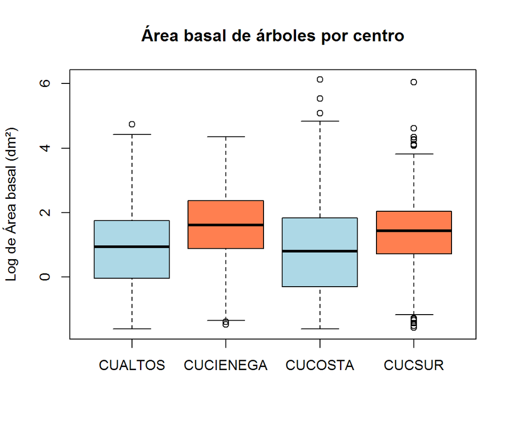

```r
boxplot(log(arbolado$AB) ~ arbolado$Centro,
        col = c("lightblue","coral"),
        main = "Área basal de árboles por centro",
        ylab = "Log de Área basal (dm²)")
```

#### Gráficas de puntos

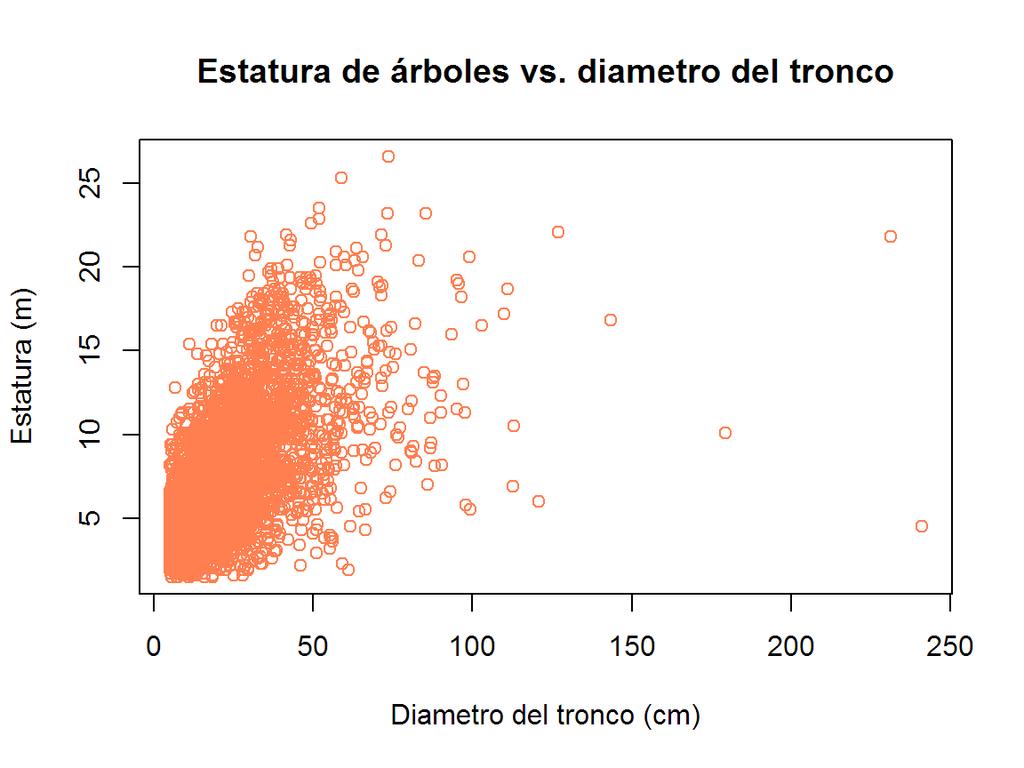

```r
plot(arbolado$Alt ~ arbolado$DTr,
        col = "coral",
        main = "Estatura de árboles vs. diametro del tronco",
        ylab = "Estatura (m)", xlab = "Diametro del tronco (cm)")
```

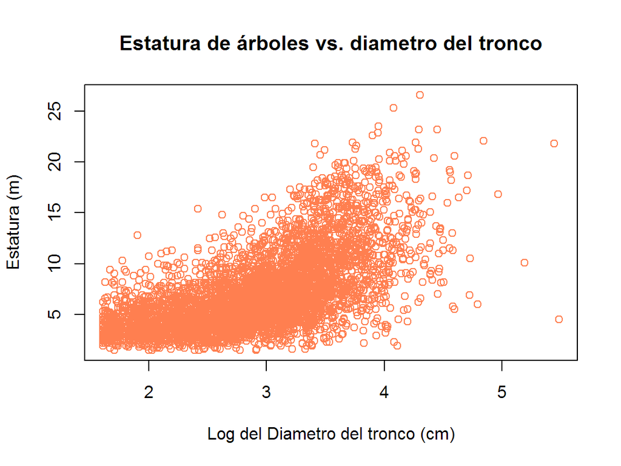

```r
plot(arbolado$Alt ~ log(arbolado$DTr),
        col = "coral",
        main = "Estatura de árboles vs. diametro del tronco",
        ylab = "Estatura (m)", xlab = "Log del Diametro del tronco (cm)")
```

Graficas de puntos pueden incluir grupos de datos

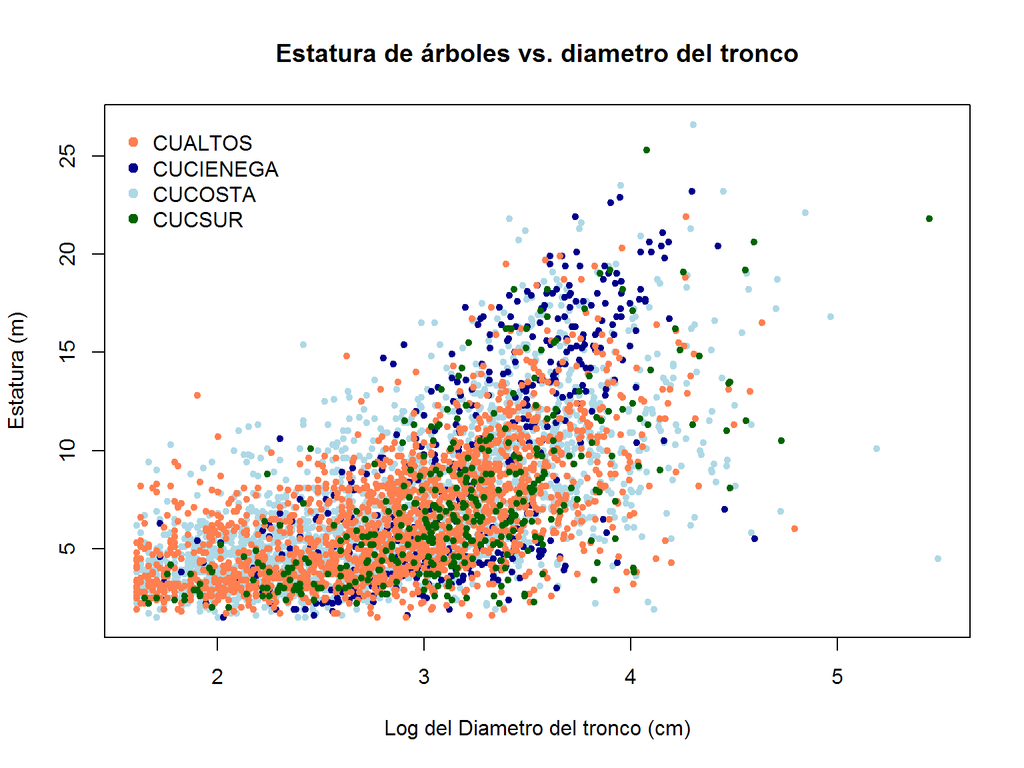

```r
colors <- c("coral","darkblue","lightblue","darkgreen")
color.index <- as.numeric(arbolado$Centro)

plot(arbolado$Alt ~ log(arbolado$DTr),
        col = colors[color.index], pch = 20,
        main = "Estatura de árboles vs. diametro del tronco",
        ylab = "Estatura (m)", xlab = "Log del Diametro del tronco (cm)")

legend( 1.5, 27, levels(arbolado$Centro),
      bty = "n", pch = c(19,19,19,19), col = colors)
```

### E. Estructuras de control

#### Funciones

Sintáxis general de definición de las funciones

> nombre_de_función <- **function**(variables_de_entrada) {  
> cuerpo de función donde se usan las variables de entrada y se genera valor de salida  
> }

Existen la dos formas de definición de las funciones:  
a) en una sola linea  
b) con el bloque encerrado en los símbolos `{}`  
Las funciones pueden ser anónimas o tener el nombre

```r
# función para quetar los espacios en principio y al final de una cadena de texto
trim <- function(x) gsub("^\\s+|\\s+$", "", x)

# función para poner primera letra de una cadena de texto como mayuscula y otras como minusculas
simpleCap <- function(x) {
    paste(toupper(substr(x, 1, 1)), tolower(substr(x, 2, nchar(x))), sep="")
}
```

Aplicacion de las funciones para depurar nombres de las especies

```r
lista_especies <- unique(as.character(arbolado$Especie))
length(lista_especies)
```

```
## [1] 150
```

```r
arbolado$Especie <- sapply(as.character(arbolado$Especie), simpleCap)
arbolado$Especie <- sapply(arbolado$Especie, trim)
lista_depurada_especies <- unique(arbolado$Especie)
arbolado$Especie <- as.factor(arbolado$Especie)

length(lista_depurada_especies)
```

```
## [1] 144
```

#### Elementos de control de flujo de ejecución

1. `if`, `else`, `else if` - estructuras condicionales
2. `for` - ciclos (loops, bucles) con un número predeterminado de iteraciones
3. `while` - ciclos con un número indefinido de iteraciones
4. `repeat` - ciclos con un número infinito de iteraciones (se usan rara vez, principalmente en elementos de interface de usuario)
5. `next`, `return` - elementos que permiten interrimpir o saltar iteraciones en los ciclos

Sintáxis general de las estructuras condicionales

> **if**(condición lógica) {  
> código para caso que la condición se cumple  
> } **else** {  
> código para caso que la condición no se cumple  
> }

Sintáxis general de los ciclos con numero predeterminado de elementos

> **for**(iterador **in** rango_de_posibles_valores_del_iterador) {  
> código del cuerpo de ciclo, donde se puede utilizar iterador como una variable  
> }

Ejemplo:

```r
for(i in 1:length(lista_depurada_especies)){
    # seleccionar registros que corresponden a una especie determinada
    tabla_especie <- arbolado[arbolado$Especie == lista_depurada_especies[i],]
    # verificar que número de árboles de la especie es mayór que 50
    if(dim(tabla_especie)[1] > 50) {
       # imprimir nombre de especie y número de árboles
       cat(paste("<h4><i>",lista_depurada_especies[i],"</i></h4>"))
       cat(paste('<pre class="r"><code>',"n =",dim(tabla_especie)[1],"</code></pre>"))
       # especificar lienzo para tres graficas
       par(mfcol = c(1, 3))
       # dibujar tres gráficas
       boxplot(tabla_especie$Alt,
          col = "coral", main = "Estatura de árboles", ylab = "Estatura (m)")
       boxplot(log(tabla_especie$DTr),
          col = "lightblue", main = "Diametro del tronco", ylab = "Log del diametro de tronco (cm)")
      plot(tabla_especie$Alt ~ log(tabla_especie$DTr),
          col = "coral",  main = "Estatura vs. diametro del tronco",
          ylab = "Estatura (m)", xlab = "Log del diametro del tronco (cm)")
    }
}
```

#### *Pithecellobium dulce*

```r
 n = 107
```

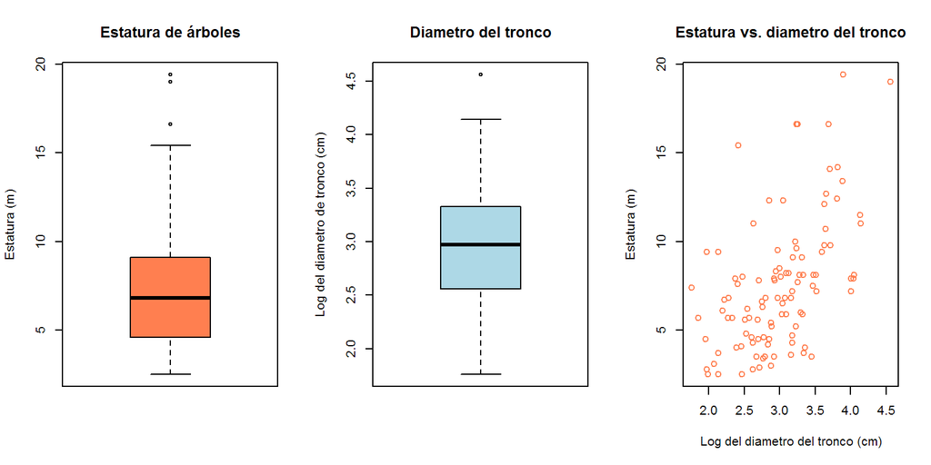

#### *Acacia macracantha*

```r
 n = 176
```

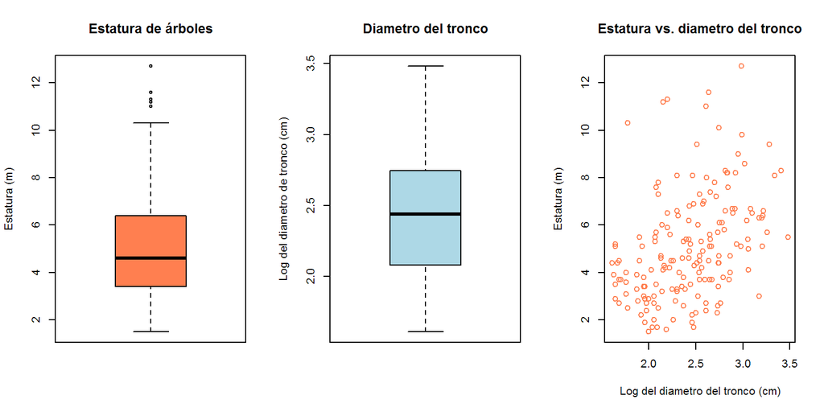

#### *Pithecellobium lanceolatum*

```r
 n = 501
```

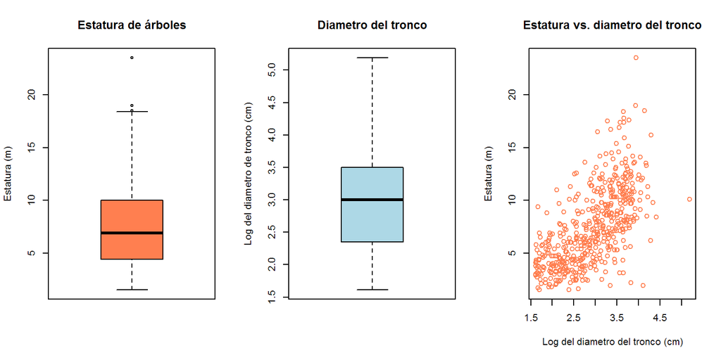

#### *Salix bonplandiana*

```r
 n = 139
```

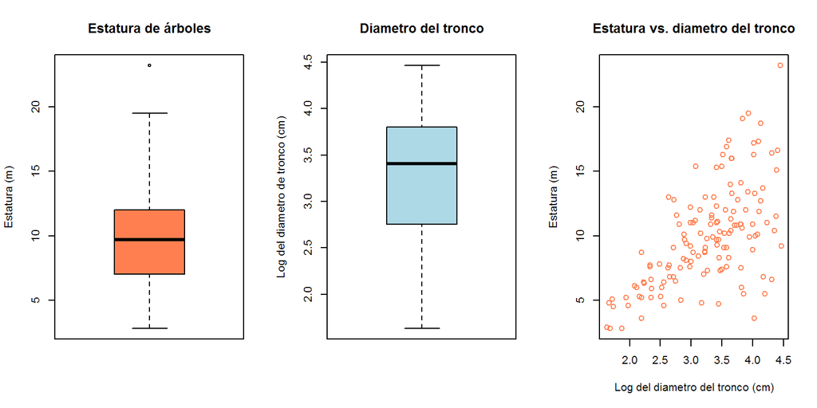

#### *Tabebuia rosea*

```r
 n = 159
```

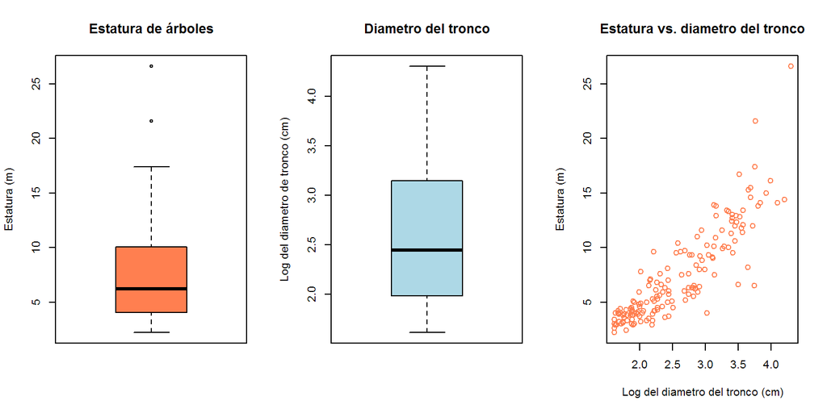

#### *Terminalia catappa*

```r
 n = 110
```

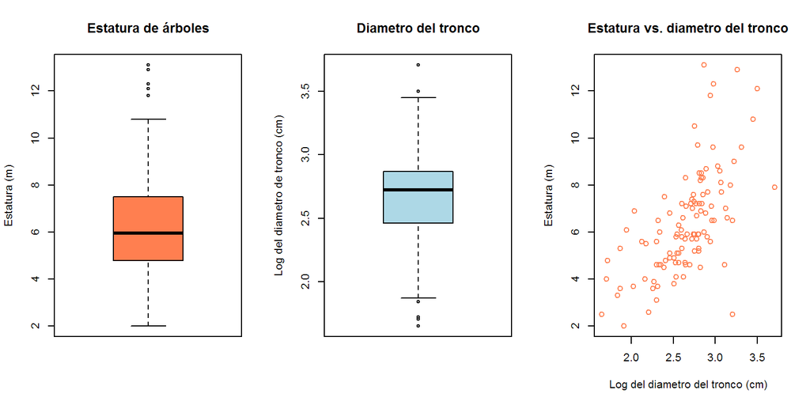

#### *Enterolobium cyclocarpum*

```r
 n = 62
```

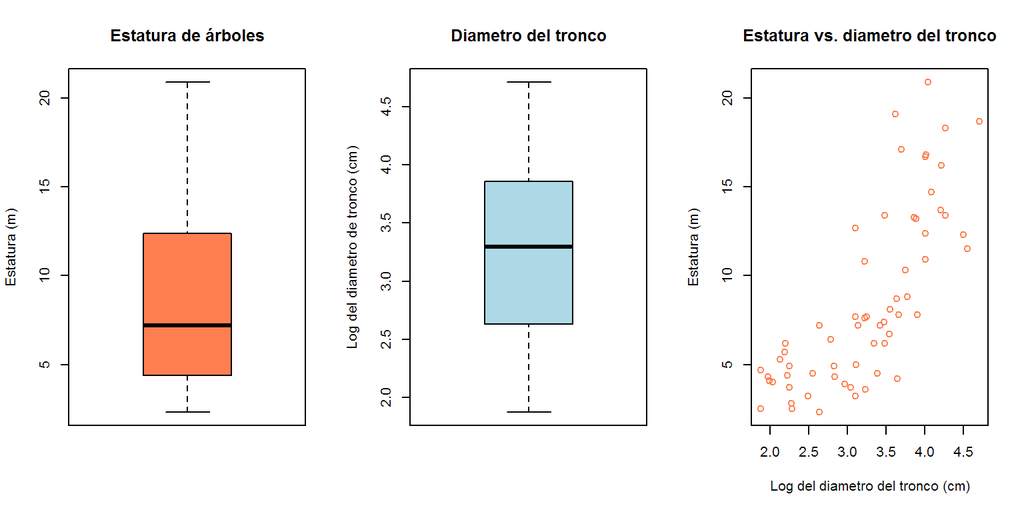

#### *Guazuma ulmifolia*

```r
 n = 329
```

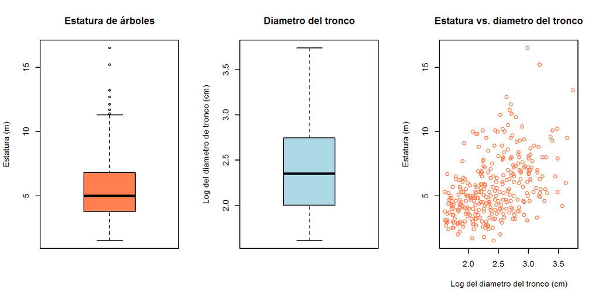

#### *Ficus benjamina*

```r
 n = 153
```

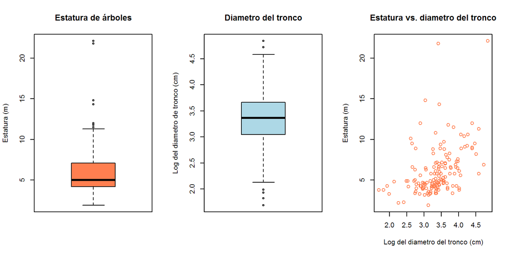

#### *Cocus nucifera*

```r
 n = 157
```

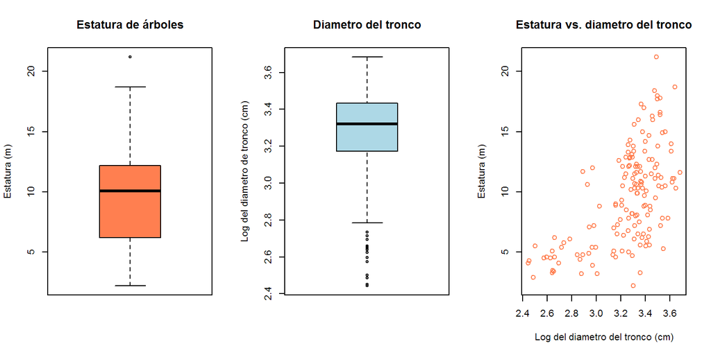

#### *Arecastrum romanzoffianum*

```r
 n = 162
```

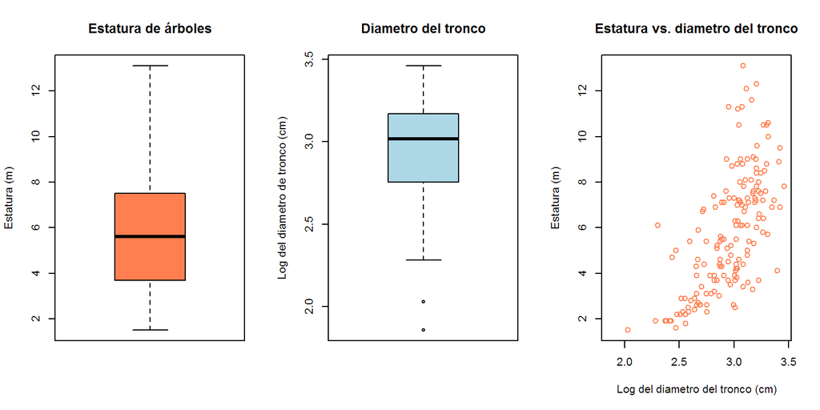

#### *Dypsis lutescens*

```r
 n = 82
```

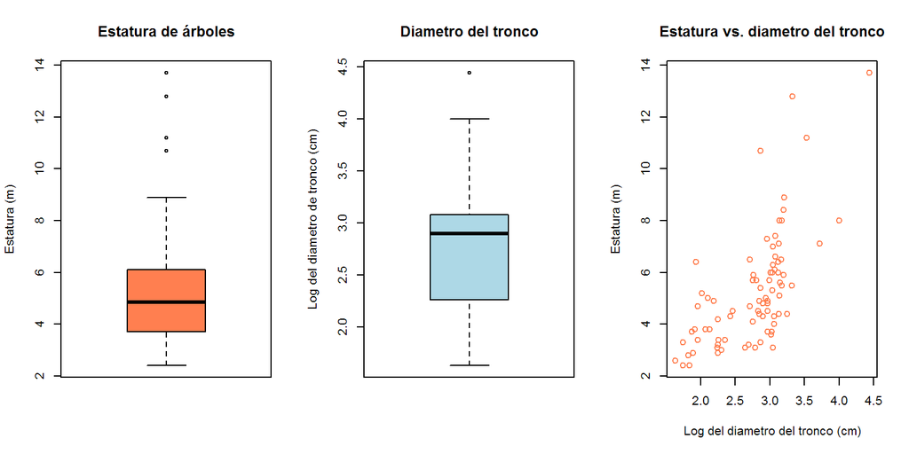

#### *Acacia farnesiana*

```r
 n = 174
```

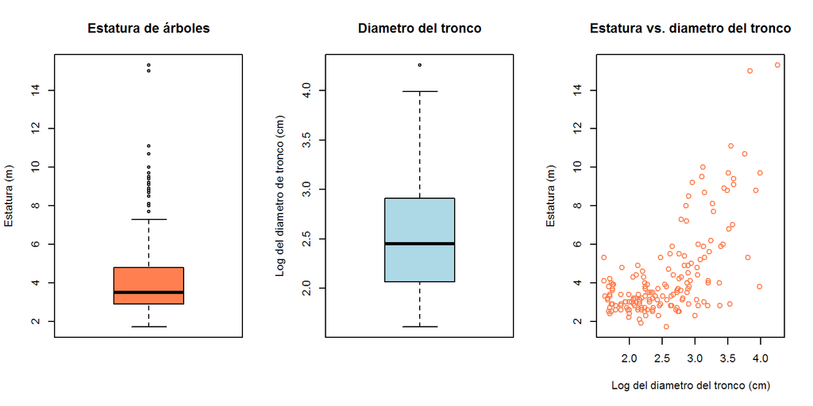

#### *Eucalyptus camaldulensis*

```r
 n = 58
```

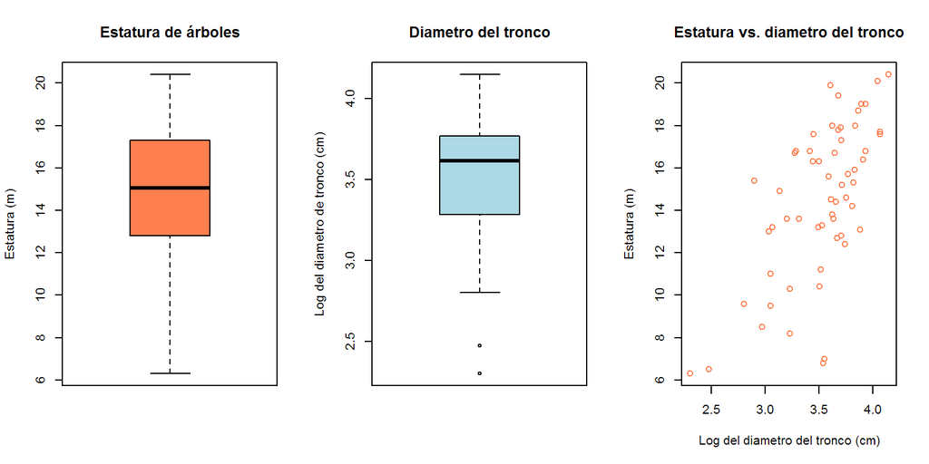

#### *Casuarina equisetifolia*

```r
 n = 145
```

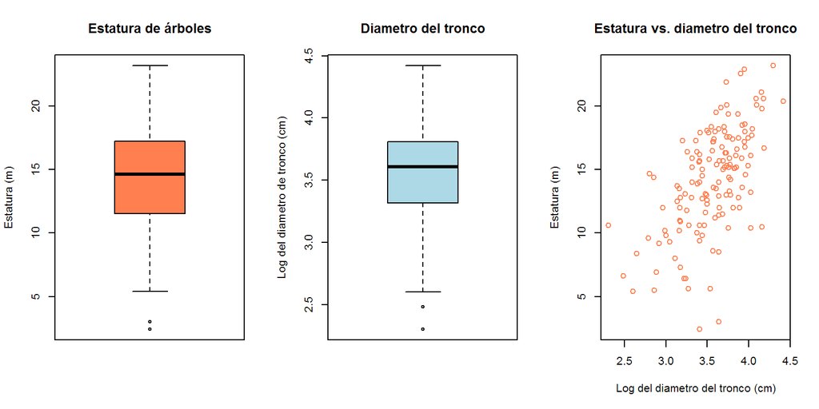

#### *Cupressus sempervirens*

```r
 n = 77
```

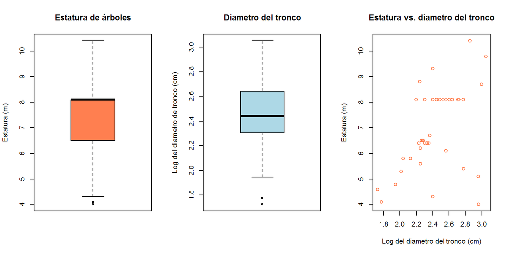

#### *Fraxinus uhdei*

```r
 n = 278
```

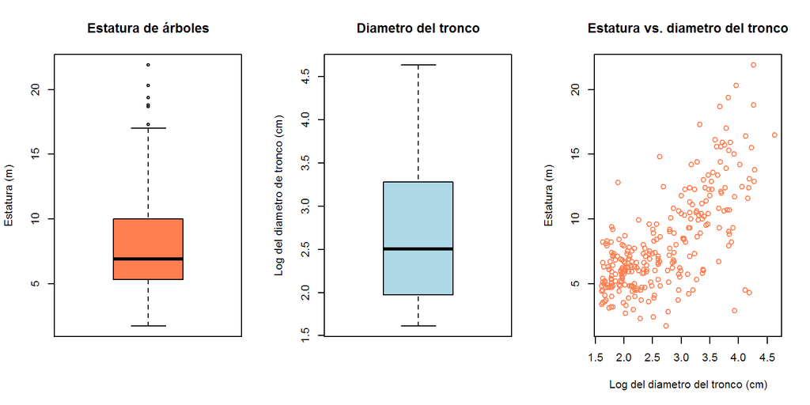